# Project: Investigating The *No-Show appointment* dataset.

```python
import pandas as pd
import numpy as np
import matplotlib.pyplot as plt
%matplotlib inline
```

## Data Wrangling

> 1. In this section, i'm exploring the dataset, the counts, types and unique values in each column.
> 2. i'm looking for duplicates, nan values or outliers values to build decisions to make in the cleaning part.
> 3. Renaming the columns to take the same name formatting would be nice.

### General Properties

```python
df = pd.read_csv('noshowappointments-kagglev2-may-2016.csv')
# df = pd.read_csv('noshowappointments-kagglev2-may-2016.csv', dtype=str)
df.head()
```

|  | PatientId | AppointmentID | Gender | ScheduledDay | AppointmentDay | Age | Neighbourhood | Scholarship | Hipertension | Diabetes | Alcoholism | Handcap | SMS_received | No-show |
| --- | --- | --- | --- | --- | --- | --- | --- | --- | --- | --- | --- | --- | --- | --- |
| 0 | 2.987250e+13 | 5642903 | F | 2016-04-29T18:38:08Z | 2016-04-29T00:00:00Z | 62 | JARDIM DA PENHA | 0 | 1 | 0 | 0 | 0 | 0 | No |
| 1 | 5.589978e+14 | 5642503 | M | 2016-04-29T16:08:27Z | 2016-04-29T00:00:00Z | 56 | JARDIM DA PENHA | 0 | 0 | 0 | 0 | 0 | 0 | No |
| 2 | 4.262962e+12 | 5642549 | F | 2016-04-29T16:19:04Z | 2016-04-29T00:00:00Z | 62 | MATA DA PRAIA | 0 | 0 | 0 | 0 | 0 | 0 | No |
| 3 | 8.679512e+11 | 5642828 | F | 2016-04-29T17:29:31Z | 2016-04-29T00:00:00Z | 8 | PONTAL DE CAMBURI | 0 | 0 | 0 | 0 | 0 | 0 | No |
| 4 | 8.841186e+12 | 5642494 | F | 2016-04-29T16:07:23Z | 2016-04-29T00:00:00Z | 56 | JARDIM DA PENHA | 0 | 1 | 1 | 0 | 0 | 0 | No |

```python
df.nunique()
```

```
PatientId          62299
AppointmentID     110527
Gender                 2
ScheduledDay      103549
AppointmentDay        27
Age                  104
Neighbourhood         81
Scholarship            2
Hipertension           2
Diabetes               2
Alcoholism             2
Handcap                5
SMS_received           2
No-show                2
dtype: int64
```

```python
df.duplicated().sum()
```

```
0
```

```python
df.isna().sum()
```

```
PatientId         0
AppointmentID     0
Gender            0
ScheduledDay      0
AppointmentDay    0
Age               0
Neighbourhood     0
Scholarship       0
Hipertension      0
Diabetes          0
Alcoholism        0
Handcap           0
SMS_received      0
No-show           0
dtype: int64
```

```python
df.describe()
```

|  | PatientId | AppointmentID | Age | Scholarship | Hipertension | Diabetes | Alcoholism | Handcap | SMS_received |
| --- | --- | --- | --- | --- | --- | --- | --- | --- | --- |
| count | 1.105270e+05 | 1.105270e+05 | 110527.000000 | 110527.000000 | 110527.000000 | 110527.000000 | 110527.000000 | 110527.000000 | 110527.000000 |
| mean | 1.474963e+14 | 5.675305e+06 | 37.088874 | 0.098266 | 0.197246 | 0.071865 | 0.030400 | 0.022248 | 0.321026 |
| std | 2.560949e+14 | 7.129575e+04 | 23.110205 | 0.297675 | 0.397921 | 0.258265 | 0.171686 | 0.161543 | 0.466873 |
| min | 3.921784e+04 | 5.030230e+06 | -1.000000 | 0.000000 | 0.000000 | 0.000000 | 0.000000 | 0.000000 | 0.000000 |
| 25% | 4.172614e+12 | 5.640286e+06 | 18.000000 | 0.000000 | 0.000000 | 0.000000 | 0.000000 | 0.000000 | 0.000000 |
| 50% | 3.173184e+13 | 5.680573e+06 | 37.000000 | 0.000000 | 0.000000 | 0.000000 | 0.000000 | 0.000000 | 0.000000 |
| 75% | 9.439172e+13 | 5.725524e+06 | 55.000000 | 0.000000 | 0.000000 | 0.000000 | 0.000000 | 0.000000 | 1.000000 |
| max | 9.999816e+14 | 5.790484e+06 | 115.000000 | 1.000000 | 1.000000 | 1.000000 | 1.000000 | 4.000000 | 1.000000 |

```python
df['Age'].value_counts()
```

```
 0      3539
 1      2273
 52     1746
 49     1652
 53     1651
        ...
 115       5
 100       4
 102       2
 99        1
-1         1
Name: Age, Length: 104, dtype: int64
```

```python
print(np.sort(df['Age'].unique()))
```

```
[ -1   0   1   2   3   4   5   6   7   8   9  10  11  12  13  14  15  16
  17  18  19  20  21  22  23  24  25  26  27  28  29  30  31  32  33  34
  35  36  37  38  39  40  41  42  43  44  45  46  47  48  49  50  51  52
  53  54  55  56  57  58  59  60  61  62  63  64  65  66  67  68  69  70
  71  72  73  74  75  76  77  78  79  80  81  82  83  84  85  86  87  88
  89  90  91  92  93  94  95  96  97  98  99 100 102 115]
```

```python
df.loc[df['Age']== -1.0]
```

|  | PatientId | AppointmentID | Gender | ScheduledDay | AppointmentDay | Age | Neighbourhood | Scholarship | Hipertension | Diabetes | Alcoholism | Handcap | SMS_received | No-show |
| --- | --- | --- | --- | --- | --- | --- | --- | --- | --- | --- | --- | --- | --- | --- |
| 99832 | 4.659432e+14 | 5775010 | F | 2016-06-06T08:58:13Z | 2016-06-06T00:00:00Z | -1 | ROMÃO | 0 | 0 | 0 | 0 | 0 | 0 | No |

```python
df.loc[df['Age']== 0]
```

|  | PatientId | AppointmentID | Gender | ScheduledDay | AppointmentDay | Age | Neighbourhood | Scholarship | Hipertension | Diabetes | Alcoholism | Handcap | SMS_received | No-show |
| --- | --- | --- | --- | --- | --- | --- | --- | --- | --- | --- | --- | --- | --- | --- |
| 59 | 7.184428e+13 | 5638545 | F | 2016-04-29T08:08:43Z | 2016-04-29T00:00:00Z | 0 | CONQUISTA | 0 | 0 | 0 | 0 | 0 | 0 | No |
| 63 | 2.366233e+14 | 5628286 | M | 2016-04-27T10:46:12Z | 2016-04-29T00:00:00Z | 0 | SÃO BENEDITO | 0 | 0 | 0 | 0 | 0 | 0 | No |
| 64 | 1.885174e+14 | 5616082 | M | 2016-04-25T13:28:21Z | 2016-04-29T00:00:00Z | 0 | ILHA DAS CAIEIRAS | 0 | 0 | 0 | 0 | 0 | 1 | No |
| 65 | 2.718818e+14 | 5628321 | M | 2016-04-27T10:48:50Z | 2016-04-29T00:00:00Z | 0 | CONQUISTA | 0 | 0 | 0 | 0 | 0 | 0 | No |
| 67 | 8.647128e+13 | 5639264 | F | 2016-04-29T08:53:02Z | 2016-04-29T00:00:00Z | 0 | NOVA PALESTINA | 0 | 0 | 0 | 0 | 0 | 0 | No |
| ... | ... | ... | ... | ... | ... | ... | ... | ... | ... | ... | ... | ... | ... | ... |
| 110345 | 1.473952e+14 | 5702537 | F | 2016-05-16T12:30:58Z | 2016-06-01T00:00:00Z | 0 | RESISTÊNCIA | 0 | 0 | 0 | 0 | 0 | 0 | No |
| 110346 | 5.577525e+12 | 5777724 | M | 2016-06-06T14:22:34Z | 2016-06-08T00:00:00Z | 0 | RESISTÊNCIA | 0 | 0 | 0 | 0 | 0 | 0 | No |
| 110454 | 6.142460e+11 | 5772400 | F | 2016-06-03T15:18:44Z | 2016-06-03T00:00:00Z | 0 | RESISTÊNCIA | 0 | 0 | 0 | 0 | 0 | 0 | No |
| 110460 | 4.321846e+13 | 5769545 | F | 2016-06-03T08:56:51Z | 2016-06-03T00:00:00Z | 0 | RESISTÊNCIA | 0 | 0 | 0 | 0 | 0 | 0 | No |
| 110507 | 4.769462e+14 | 5786918 | F | 2016-06-08T09:04:18Z | 2016-06-08T00:00:00Z | 0 | MARIA ORTIZ | 0 | 0 | 0 | 0 | 0 | 0 | No |

3539 rows × 14 columns

```python
df['Handcap'].value_counts()
```

```
0    108286
1      2042
2       183
3        13
4         3
Name: Handcap, dtype: int64
```

```python
df.dtypes
```

```
PatientId         float64
AppointmentID       int64
Gender             object
ScheduledDay       object
AppointmentDay     object
Age                 int64
Neighbourhood      object
Scholarship         int64
Hipertension        int64
Diabetes            int64
Alcoholism          int64
Handcap             int64
SMS_received        int64
No-show            object
dtype: object
```

```python
df.rename(columns={'PatientId':'Patient Id', 'AppointmentID':'Appointment Id', 'ScheduledDay':'Scheduled Day',
                        'AppointmentDay':'Appointment Day','Nighbourhood':'Neighbourhood', 'Hipertension':'Hypertension',
                        'Handcap':'Handicap', 'No-show':'No Show', }, inplace=True)
df.rename(columns=lambda x: x.strip().lower().replace(" ", "_"), inplace=True)
df.columns
```

```
Index(['patient_id', 'appointment_id', 'gender', 'scheduled_day',
       'appointment_day', 'age', 'neighbourhood', 'scholarship',
       'hypertension', 'diabetes', 'alcoholism', 'handicap', 'sms_received',
       'no_show'],
      dtype='object')
```

> **Conclusions**:
> 1. The data doesn't contain nans or duplicates
> 2. The Age column have obvious outliers
> 3. Some columns need type change like the date columns and patient id
> 4. Split the data into show and no_show sub-dataframes for ease of comparison

### Data Cleaning (Removing Outliers and Changing Types!)

```python
print(len(df))
df.drop(df[df['age'] == -1].index, inplace = True)
len(df)
```

```
110527
```

```
110526
```

```python
age_mean= int(df['age'].mean())
age_mean
```

```
37
```

```python
# df['age'] = df['age'].replace(0, age_mean)
# df['age'] = df['age'].mask(df['age'] > 100, age_mean)
df.drop(df[df['age'] > 100].index, inplace = True)
```

```python
df['patient_id'] = df['patient_id'].astype('int64')
df['scheduled_day'] = pd.to_datetime(df['scheduled_day'])
df['appointment_day'] = pd.to_datetime(df['appointment_day'])
df['scheduled_weekday'] = df['scheduled_day'].dt.dayofweek
df['appointment_weekday'] = df['appointment_day'].dt.dayofweek
```

```python
df['scheduled_weekday'].unique()
```

```
array([4, 2, 1, 3, 0, 5], dtype=int64)
```

```python
df['appointment_weekday'].unique()
```

```
array([4, 1, 0, 2, 3, 5], dtype=int64)
```

```python
df.describe()
```

|  | patient_id | appointment_id | age | scholarship | hypertension | diabetes | alcoholism | handicap | sms_received | scheduled_weekday | appointment_weekday |
| --- | --- | --- | --- | --- | --- | --- | --- | --- | --- | --- | --- |
| count | 1.105190e+05 | 1.105190e+05 | 110519.000000 | 110519.000000 | 110519.000000 | 110519.000000 | 110519.000000 | 110519.000000 | 110519.000000 | 110519.000000 | 110519.000000 |
| mean | 1.474860e+14 | 5.675303e+06 | 37.084519 | 0.098273 | 0.197251 | 0.071870 | 0.030402 | 0.022213 | 0.321040 | 1.852007 | 1.858251 |
| std | 2.560826e+14 | 7.129600e+04 | 23.103165 | 0.297684 | 0.397925 | 0.258274 | 0.171692 | 0.161441 | 0.466878 | 1.378501 | 1.371657 |
| min | 3.921700e+04 | 5.030230e+06 | 0.000000 | 0.000000 | 0.000000 | 0.000000 | 0.000000 | 0.000000 | 0.000000 | 0.000000 | 0.000000 |
| 25% | 4.172457e+12 | 5.640284e+06 | 18.000000 | 0.000000 | 0.000000 | 0.000000 | 0.000000 | 0.000000 | 0.000000 | 1.000000 | 1.000000 |
| 50% | 3.172598e+13 | 5.680569e+06 | 37.000000 | 0.000000 | 0.000000 | 0.000000 | 0.000000 | 0.000000 | 0.000000 | 2.000000 | 2.000000 |
| 75% | 9.438963e+13 | 5.725522e+06 | 55.000000 | 0.000000 | 0.000000 | 0.000000 | 0.000000 | 0.000000 | 1.000000 | 3.000000 | 3.000000 |
| max | 9.999816e+14 | 5.790484e+06 | 100.000000 | 1.000000 | 1.000000 | 1.000000 | 1.000000 | 4.000000 | 1.000000 | 5.000000 | 5.000000 |

```python
df.dtypes
```

```
patient_id                           int64
appointment_id                       int64
gender                              object
scheduled_day          datetime64[ns, UTC]
appointment_day        datetime64[ns, UTC]
age                                  int64
neighbourhood                       object
scholarship                          int64
hypertension                         int64
diabetes                             int64
alcoholism                           int64
handicap                             int64
sms_received                         int64
no_show                             object
scheduled_weekday                    int64
appointment_weekday                  int64
dtype: object
```

```python
df['no_show'] = df['no_show'].str.replace('No', 'Show')
df['no_show'] = df['no_show'].str.replace('Yes', 'No Show')
```

```python
show= df.loc[df['no_show'] == 'Show']
no_show= df.loc[df['no_show'] == 'No Show']
```

> **Notes**:
> 1. There are more than 3000 patient marked with age "0", I couldn't determine whether this means babies or wrong values so i left them considered as babies. on the otherhand patients more than 100 years had a little number so i deleted them to avoid outliers.
> 2. I created a weekday column to conclude on what week of the day do patients tend to not show more, but it has only 6 days. I'm assuming Sunday has zero appointment since it's the weekend but still a litte suspicious to me.
> 3. I don't know why would the doctor expect a message from a patient that shows on time so i wanted to edit the values of column sms in show sub-dataframe to be all zero but it may not affect my conclusions anyway.

## Exploratory Data Analysis

### Research Question 1: How many patient miss their appointmen

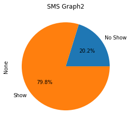

```python
df.groupby(["no_show"]).size().plot.pie(title= 'SMS Graph2',autopct='%1.1f%%')
```

### Research Question 2: How many patients send SMS before their appointment

```
sms_received
0    12532
1     9784
dtype: int64
```

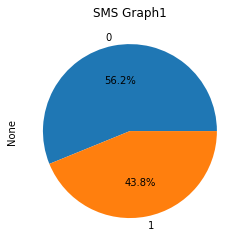

```python
no_show.groupby(["sms_received"]).size().plot.pie(title= 'SMS Graph1',autopct='%1.1f%%')
no_show.groupby(["sms_received"]).size()
```

```
no_show  sms_received
No Show  0               12532
         1                9784
Show     0               62506
         1               25697
dtype: int64
```

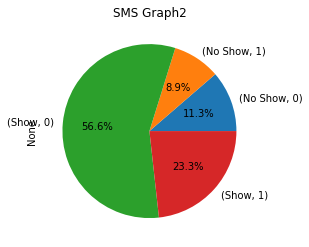

```python
df.groupby(["no_show", "sms_received"]).size().plot.pie(title= 'SMS Graph2',autopct='%1.1f%%')
df.groupby(["no_show", "sms_received"]).size()
```

```python
# df.groupby(["no_show", "sms_received"]).size().plot.hist(title= 'SMS Graph2')
```

### Research Question 3 : What ages tend to not show or to show?

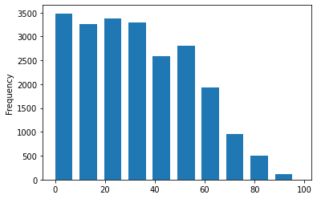

```python
no_show['age'].plot.hist(width=7)
# no_show.groupby(['age']).plot.bar(bins=[0, 20, 40, 60, 80, 100])
```

### Research Question 4 : What column affects tendecy to not show ?

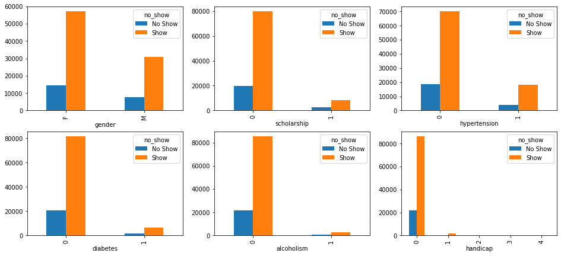

```python
columns=[ 'gender', 'scholarship', 'hypertension','diabetes', 'alcoholism', 'handicap']
fig = plt.figure(figsize=(16, 11))
for i in range(len(columns)):
    ax = fig.add_subplot(3, 3, i+1)
#     df.groupby(['no_show',columns[i]]).plot.hist(title=columns[i])
    df.groupby([columns[i], 'no_show'])[columns[i]].count().unstack('no_show').plot(ax=ax, kind='bar')
#     plt.show()
#     plt.close()
```

### Research Question 5 : What's the gender effect?

```
no_show  gender
No Show  F         14591
         M          7725
Show     F         57241
         M         30962
dtype: int64
```

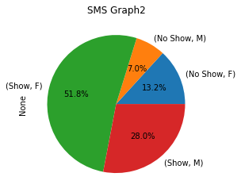

```python
df.groupby(["no_show", "gender"]).size().plot.pie(title= 'SMS Graph2',autopct='%1.1f%%')
df.groupby(["no_show", "gender"]).size()
```

```
gender
F    14591
M     7725
dtype: int64
```

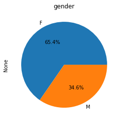

```python
no_show.groupby(["gender"]).size().plot.pie(title= 'gender',autopct='%1.1f%%')
no_show.groupby(["gender"]).size()
```

```
gender
F    57241
M    30962
dtype: int64
```

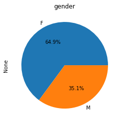

```python
show.groupby(["gender"]).size().plot.pie(title= 'gender',autopct='%1.1f%%')
show.groupby(["gender"]).size()
```

### Research Question 6: On what day do patients tend to miss their appointments more?

```
no_show  appointment_weekday
No Show  0                       4689
         1                       5152
         2                       5093
         3                       3336
         4                       4037
         5                          9
Show     0                      18023
         1                      20487
         2                      20774
         3                      13908
         4                      14981
         5                         30
dtype: int64
```

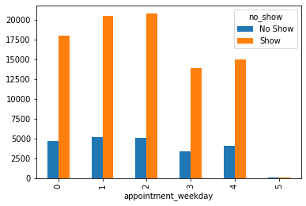

```python
df.groupby(['appointment_weekday', 'no_show'])['appointment_weekday'].count().unstack('no_show').plot(kind='bar')
df.groupby(['no_show','appointment_weekday']).size()
```

### Research Question 7 : What neighbourhood residents seem to miss their appointment more?

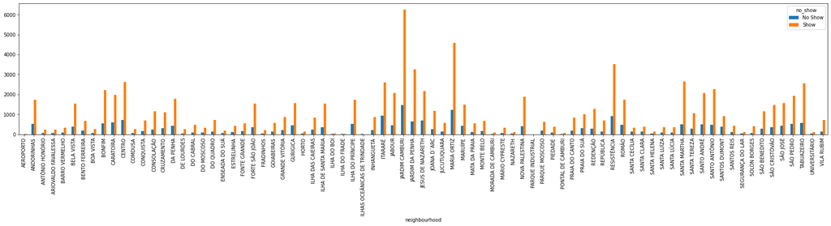

```python
df.groupby(['neighbourhood', 'no_show'])['appointment_weekday'].count().unstack('no_show').plot(kind='bar', figsize=(30, 5))
```

```python
no_show['neighbourhood'].value_counts()
```

```
JARDIM CAMBURI                 1465
MARIA ORTIZ                    1219
ITARARÉ                         923
RESISTÊNCIA                     906
CENTRO                          703
                               ...
PONTAL DE CAMBURI                12
ILHA DO BOI                       3
ILHAS OCEÂNICAS DE TRINDADE       2
ILHA DO FRADE                     2
AEROPORTO                         1
Name: neighbourhood, Length: 80, dtype: int64
```

## Conclusions

> **Question1**: Overall, 20% of the patients missed their appointments.

> **Question4**: No noticeable difference between show and didn't show data in the categorical Columns so you can't expect whether the patient is more likely to miss his appointment or not based on these columns.

> **Question5**: Apparently females(65%) miss their appointments more, but they also seem to show more.

> **Question6**: The difference is slightly noticed between the weekdays so there may not be any correlations.